Estadística 1 | 2020

# Guía de Clase del TP2: Probabilidad

Estadística 1 | 2020

Docentes: Patricia M. Acetta y Carlos A. Alesso

# Probabilidad

## Por qué es importante ver el tema Probabilidad?

La probabilidad conforma los cimientos sobre los cuales se construyen los métodos importantes de la estadística inferencial que veremos en unidades posteriores.

Los ingenieros agrónomos se ven enfrentados a la toma de decisiones en situaciones en donde la incertidumbre, el azar y el riesgo, son relevantes.

# Definiciones

- Un **experimento aleatorio** es cualquier operación o proceso físico que produce un resultado o una observación de una variable y cuyo resultado no puede predecirse con exactitud. No tiene un sólo resultado posible, sino un conjunto de resultados asociados a él.
- Un **suceso** es cualquier conjunto de resultados o consecuencias de un procedimiento.
- Un **suceso simple** es un resultado o un suceso que ya no puede desglosarse en componentes más simples.
- El **espacio muestral** de un procedimiento se compone de todos los sucesos simples posibles. Es decir, el espacio muestral está formado por todos los resultados que ya no pueden desglosarse más.

**Notación de probabilidades**

- P denota una probabilidad.
- A, B y C denotan sucesos específicos.
- P(A) denota la probabilidad de que ocurra el suceso A.

**Reglas generales de la probabilidad**

Regla 1. 0 ≤ P(A) ≤ 1 para cualquier suceso A  
Regla 2. P(S) = 1

**Suceso complementario**

El complemento de un suceso A, denotado por $\overline{A}$, consiste en todos los resultados en los cuales el suceso A no ocurre.

Para cualquier suceso A:

$P(\text{no ocurra A}) = P(\overline{A}) = 1 − P(A)$

## Ejercicio 1

Se disponen de datos de 320 lotes clasificados por producción de tres grupos de productores (A, B y C). Las clasificaciones se realizaron según el nivel de la producción de cada lote (Alto, Medio y Bajo).

```
##      Nivel_Produccion
## Grupo Alto Bajo Medio
##     A   20   75    25
##     B   10   62    18
##     C   50   33    27
```

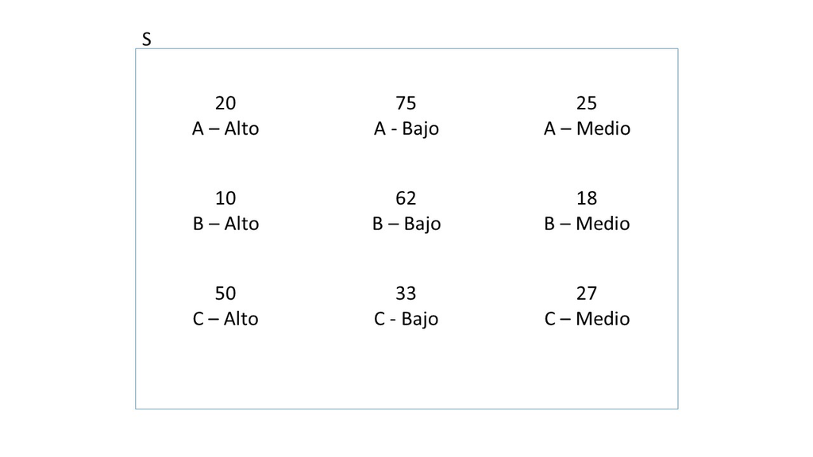

¿Cuál es la Probabilidad de que el un lote sea del Grupo A?

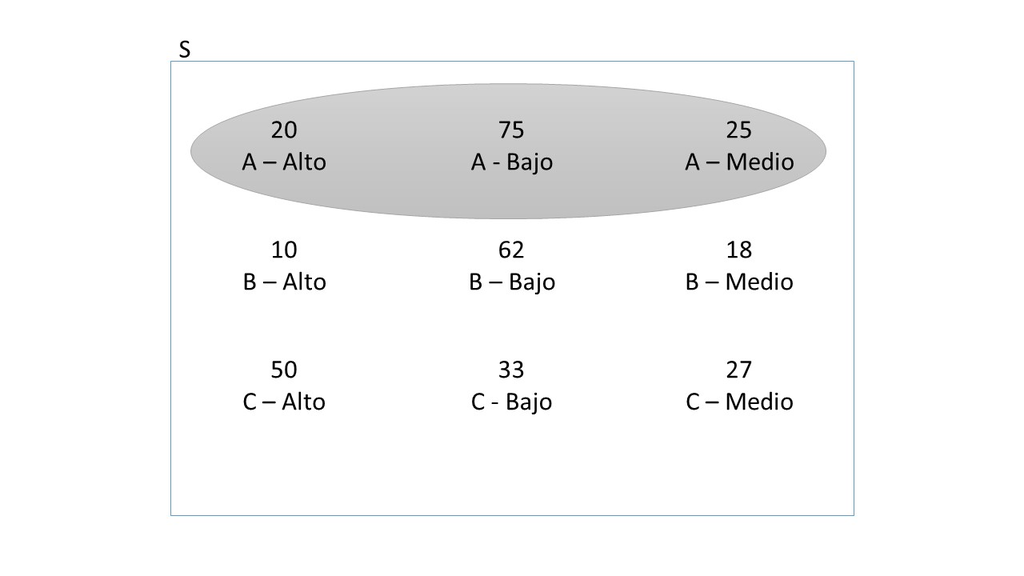

$P(A) = \frac{(20+75+25)}{320} = 0.375$

En R:

```r
P_A <- (20+75+25)/320
P_A    # 120/320
```

```
## [1] 0.375
```

**Suceso Complementario**

¿Cuál es la Probabilidad de que un lote no sea del Grupo A?

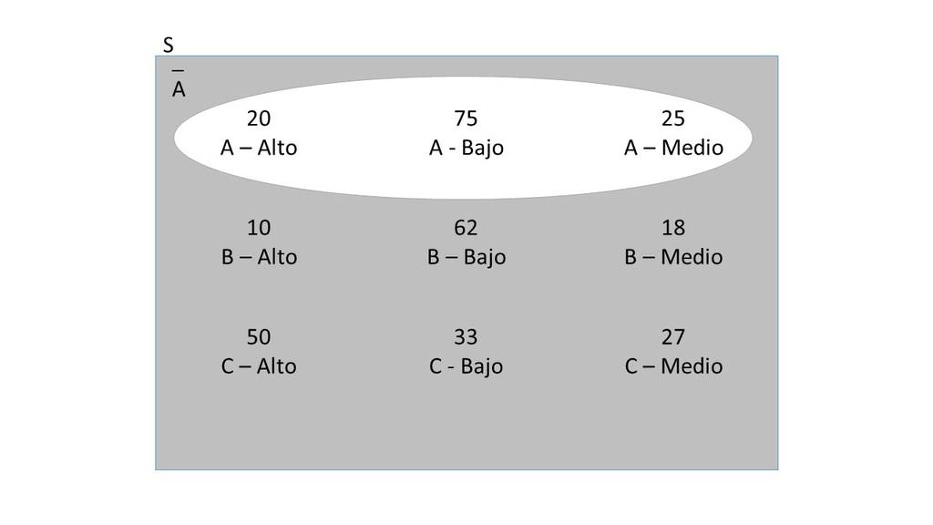

$P(\text{no sea del grupo A}) = P(\overline{A}) = 1 - P(A) = 1 - 0.375 = 0.625$

En R:

```r
P_noA <- 1 - P_A
P_noA
```

```
## [1] 0.625
```

## Regla de la suma

*Expresión: P(A o B)*

La probabilidad de que ocurra el suceso A o de que ocurra el suceso B (o de que ambos ocurran), como único resultado de un procedimiento.

Para calcular la probabilidad de que ocurra el suceso A o el suceso B, primero debemos obtener el número total de maneras en que puede ocurrir A y de maneras en que puede ocurrir B, pero calculamos ese total sin contar cada resultado más de una vez.

La palabra clave es “o”.

**Suceso compuesto**

Es cualquier suceso que combina dos o más sucesos.

**Notación de la regla de la suma**

P(A o B): P(en un solo ensayo, ocurre el suceso A u ocurre el suceso B o ambos ocurren)

**Cómo se calcula?**

1. Calcule el número total de formas en que A puede ocurrir
2. Calcule el número de formas en que B puede ocurrir
3. Verificar que ningún resultado se cuente más de una vez (si ésto ocurre debe restar las cuentas de más)

**Regla formal de la suma**

$P(A o B) = P(A) + P(B) - P(A y B)$

*P(A y B) denota la probabilidad de que A y B ocurran al mismo tiempo*

**Tener en cuenta:**

Los sucesos A y B son **mutuamente excluyente** cuando ambos no pueden ocurrir al mismo tiempo (no se superponen).

$\underline{Video}$

https://youtu.be/d2M0qv-UMzA

**Siguiendo con el Ejercicio 1**

Siguiendo el ejemplo de los Lotes de productores…

**Sucesos mutuamente excluyentes**

¿Cuál es la probabilidad de que un lote de productres sea del Grupo A o del Grupo B?

*Son sucesos mutuamente excluyentes porque si el lote es del grupo A, no puede ser del grupo B*

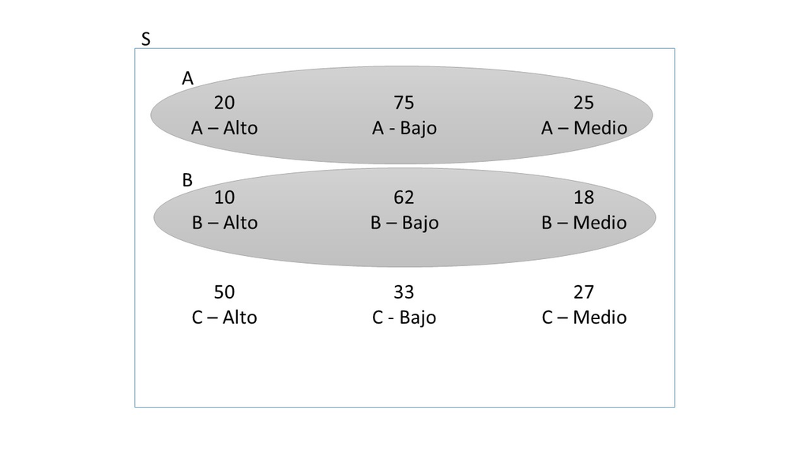

$P(A o B) = P(A) + P(B)$

P(A) lo calculamos antes

P(B) = (10 + 62 + 18) / 320

En R:

```r
P_A
```

```
## [1] 0.375
```

```r
P_B <- (10+62+18)/320
P_B
```

```
## [1] 0.28125
```

```r
P_A + P_B
```

```
## [1] 0.65625
```

$P(AoB) = P(A) + P(B) = 0.375+0.28125 = 0.65625$

**Sucesos No mutuamente excluyentes**

¿Cuál es la probabilidad de que un lote de productores sea del Grupo A o Nivel de Producción Medio?

*NO son sucesos mutuamente excluyentes porque si el lote es del grupo A (A), puede ser además del Nivel de Producción medio (M)*

*Si sumo las dos probabilidades P(A) + P(M), estoy sumando dos veces lo mismo, por lo tanto debo restar la intersección*

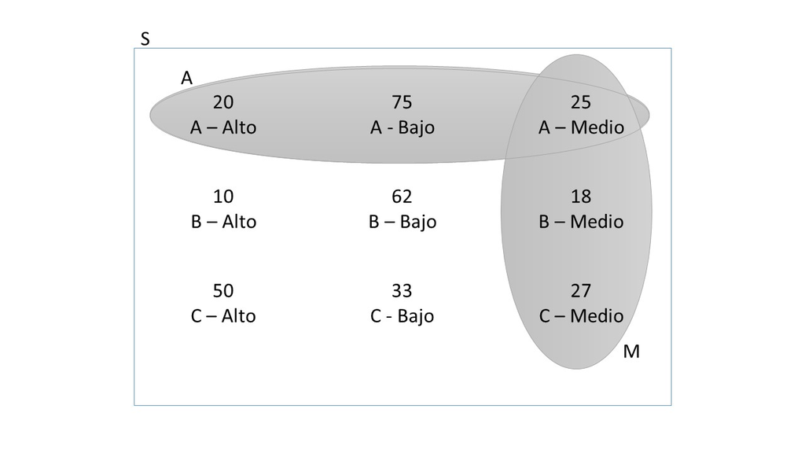

$P(A o M) = P(A) + P(M) - P(A \cap M)$

P(A)lo calculamos antes

En R:

```r
P_A   # 120/320
```

```
## [1] 0.375
```

```r
P_M <- (25+18+27)/320
P_M   # 70/320
```

```
## [1] 0.21875
```

```r
P_AinterseccionM <- 25/320
P_AinterseccionM
```

```
## [1] 0.078125
```

```r
P_A + P_M - P_AinterseccionM
```

```
## [1] 0.515625
```

$P(AoM) = P(A) + P(M) - P(A \cap M)= 120/320 + 70/320 - 25/320 = 0.5156$

## Regla de la Multiplicación

**Para sucesos independientes**

Dos sucesos A y B son independientes si el conocimiento de que ha ocurrido uno de ellos no cambia la probabilidad de que ocurra el otro.

La palabra clave es “y”.

Expresión:$P(A y B)$

**Regla formal de la multiplicación** $P(A y B) = P(A) * P(B|A)$

Si A y B son independientes: $P(A y B) = P(A) * P(B)$ *($P(B) = P(B|A)$)*

Si A y B son dependientes: $P(A y B) = P(A \cap B) = P(A) * P(B|A)$ *($P(B|A) = \frac{P(A \cap B)} {P(A)}$)*

$\underline{Videos}$

**Regla de multiplicación para eventos independientes**

Probabilidad compuesta de eventos independientes:

https://youtu.be/jn-qNXytMd0

Ejemplos de eventos independientes:

https://youtu.be/8xRc983PBN4

**Regla de la multiplicación para eventos dependientes**

Probabilidad dependiente:

https://youtu.be/9mg7Zcup_dk

Probabilidad independiente y dependiente:

https://youtu.be/KTF0o-LZYnk

https://www.youtube.com/watch?v=d4yIg-nEk-M

## Probabilidad condicional

https://es.khanacademy.org/math/probability/probability-geometry/conditional-probability-geo/a/conditional-probability-using-two-way-tables

**Ejemplo**

Siguiendo el ejemplo de los Lotes de productores…

¿Cuál es la probabilidad de que un lote de productores sea del Grupo A **y** Nivel de Producción Medio?

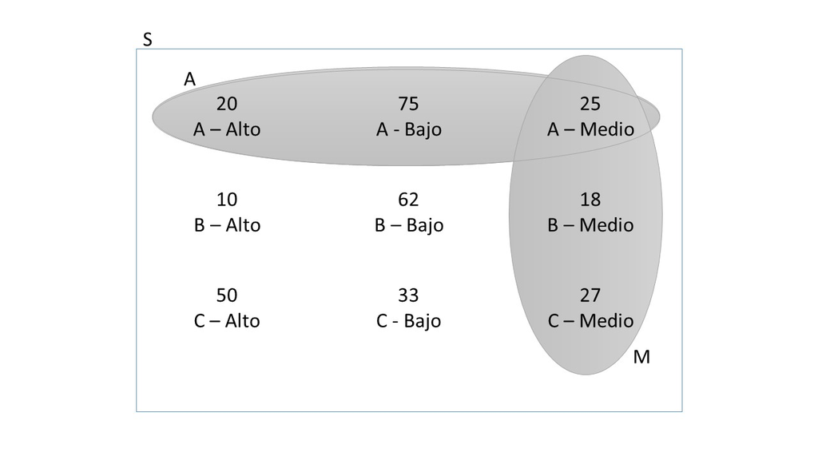

Primero necesitamos saber si estos sucesos son o no independientes.

- Si A y B son sucesos **independientes**: $P(P(A\cap B) = P(A)P(B)$

-Si A y B **no son independientes**: $P(A y B) = P(A \cap B) = P(A) \cdot P(B | A)$

**Probabilidad condicional** de $B$ dado que ocurrió $A$: $P(B | A) = \dfrac{P(A \cap B)}{P(A)}$

En el ejemplo:

$$\begin{align}
P(A \cap M) &= P(A) P(M) \\
\dfrac{25}{320} &= \dfrac{3}{8} \cdot \dfrac{7}{32} \\
0.078125 &\neq 0.0820312
\end{align}$$
Como no se umple la igualdad anterior, asumimos que los sucesos *No** son independientes.

En R:

```r
P_A
```

```
## [1] 0.375
```

```r
P_M
```

```
## [1] 0.21875
```

```r
P_A_M <- P_A * P_M
```

Calculamos la probabilidad de $M$ dado que ocurra $A$ es (condicional):

$$P(M | A) = \frac{\dfrac{25}{320}}{\dfrac{120}{320}} = \dfrac{25}{120} = 0.2083333$$

En R:

```r
P_MdadoA <- P_AinterseccionM / P_A
P_MdadoA
```

```
## [1] 0.2083333
```

Finalmente calculamos la probabilidad de que ocurran $A$ y $B$ a la vez:

$$\begin{align}
P(A \cap M) &= P(A) \cdot P(M | A) \\
&= 0.375 \cdot 0.2083333 \\
&= 0.078125
\end{align}$$

En R:

```r
P_A * P_MdadoA
```

```
## [1] 0.078125
```

# Otros ejemplos

## Ejercicio 2

En una chacra se extraen al azar hojas de distintas plantas correspondientes a diversas especies y con todas ellas se conforma una muestra en la cual se contabiliza el n°de hojas sanas y el n° de hojas enfermas. La información se resume en la siguiente tabla:

```
##             Hojas
## Especie      enfermas sanas
##   Durazneros       10    30
##   Manzanos         55    65
##   Perales          58    82
```

Vamos a hallar las siguientes probabilidades:

1. La probabilidad de que al elegir una hoja al azar de la muestra ea de peral y esté enferma.
2. La probabilidad de que, al extraer una hoja de la muestra, esta sea de manzano.
3. La probabilidad de que, si se extrajo hoja de manzano, esta esté enferma.
4. La probabilidad de que, si se extrajo una hoja enferma, esta sea de duraznero.

**Comenzamos…**

1. Desde el EntornoVirtual, en la pestaña “Trabajos Prácticos”, dentro de la carpeta “Datos”, se encuentra el archivo `especies.xlsx`. Hacer click con el botón derecho del mousse y vamos a “Guardar enlace como…”
2. Importamos los datos:

```r
# activamos el paquete `readxl`
library(readxl)

datos <- read_xlsx("especies.xlsx")
```

3. Para mejor organización, vamos a calcular las frecuencias marginales (son los totales por filas y por columnas):

```r
# primero modificamos nuestra tabla, para que sea de doble entrada
datos <- xtabs(Número ~ Especie + Hojas, datos)

#agregamos los margenes a las filas y a las columnas
addmargins(datos)
```

```
##             Hojas
## Especie      enfermas sanas Sum
##   Durazneros       10    30  40
##   Manzanos         55    65 120
##   Perales          58    82 140
##   Sum             123   177 300
```

**Resolvemos…**

1. La probabilidad de que al elegir una hoja al azar de la muestra sea de peral y esté enferma.

La Probailidad que sea Peral y esté enferma (ver en la tabla)

La combinación de fila *Perales* y columna *enfermas*, nos indica un número de hojas de 58, sobre el total de hojas analizadas: 300.

```r
P_peral_enferma <- 58/300
```

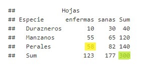

$P(Peral \cap Enferma)$ = 58/300

2. La probabilidad de que, al extraer una hoja de la muestra, esta sea de manzano.

```r
P_manzano <- (55+65)/300
```

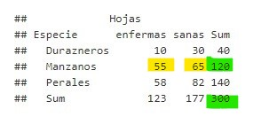

$P(M)$ = (55+65)/300 = 120/300

3. La probabilidad de que, si se extrajo hoja de manzano, esta esté enferma.

$P(E|M) = \dfrac{ P(M \cap E) } { P(M)}$

```r
# probabilidad que sea de manzano (ya lo calculamos antes)
P_manzano
```

```
## [1] 0.4
```

$P(M \cap E)$ = 55/300

```r
# probabilidad que manzano enfermo
P_manzano_enfermo <- 55/300
```

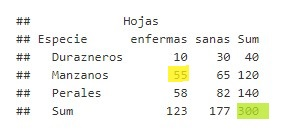

Por lo tanto la probabilidad $P(E|M)$ es:

```r
P_manzano_enfermo / P_manzano
```

```
## [1] 0.4583333
```

$P(E|M)$ = 55/120

4. La probabilidad de que, si se extrajo una hoja enferma, esta sea de duraznero.

$P(D|E) = \dfrac{ P(D \cap E) } { P(E)}$

$P(E)$

```r
# probabilidad que esté enferma
P_enferma <- 123/300
```

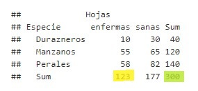

```r
# probabilidad que manzano enfermo
P_durazno_enfermo <- 10/300
```

[figure not shown]

```r
P_durazno_enfermo / P_enferma
```

```
## [1] 0.08130081
```

## Ejercicio 3

Se conoce que en una colmena existen aproximadamente 50 abejas macho y 300 abejas hembra. Si se eligen 3 abejas sin reposición hallar las siguientes probabilidades:

1. que las tres sean hembras
2. que las dos primeras sean machos y la tercera sea hembra
3. que por lo menos una sea hembra

**Resolvemos…**

Datos:

- Cantidad de hembras (H): 300
- Cantidad de machos (M): 50
- Total de abejas: 350

**a. Si se eligen 3 abejas sin reposición, la probabilidad que las tres sean hembras**

P(H) = 300 / 350

```r
P_H <- 300/350
```

P(HyHyH) = 300/350 * 299/349 * 298/348

```r
P_HyHyH <- P_H * 299/349 * 298/348
P_HyHyH
```

```
## [1] 0.628834
```

P(HyHyH) = 0.6288

*Voy restando en los numeradores y denominadores porque dice que es **sin reposición***

**b. que las dos primeras sean machos y la tercera sea hembra**

P(M) = 50 / 350

```r
P_M <- 50/350
```

P(MyMyH) = 50/350 * 49/349 * 300/348

```r
P_MyMyH <- P_M * 49/349 * 300/348
P_MyMyH
```

```
## [1] 0.01729078
```

P(MyMyH) = 0.0173

**c. que por lo menos una sea hembra**

*Ya no importa el orden si al menos hay una hembra, pude haber mas*

*Por lo tanto busco todas las alternativas posibles y las sumo o por medio del suceso complementario, a 1 le resto la probabilidad que todos sean machos*

P(MyMyM) = 50/350 * 49/349 * 48/348

```r
P_MyMyM <- P_M * 49/349 * 48/348

1 - P_MyMyM
```

```
## [1] 0.9972335
```

P(al menos una sea Hembra) = 0.99723

Material preparado por [Cátedra de Estadística FCA-UNL](https://github.com/estadistica-fcaunl/)